# Logistische Regression · 🔍

```r
library(tidyverse)

library(broom)     # tidy model data
library(patchwork) # combine ggplots
library(ggthemes)  # ggplot Stata theme
library(estimatr)  # robust standard-errors
```

```r
##  tidy lm model results with broom (and ggplot)

tidy_lm <- function(fit) {
  tidy(fit) %>% mutate_if(is.numeric, round, 2)
}

glance_lm <- function(fit) {
  glance(fit) %>%
    select(r.squared, adj.r.squared, statistic, p.value, df, nobs) %>%
    mutate_if(is.numeric, round, 2)
}

plot_lm <- function(fit,   bw = 25) {
  dt_pl<-
    augment(fit) %>%
    mutate(einkommen_geschaetzt = .fitted,
           residuen = .resid)

  pl1 <-
    ggplot(dt_pl, aes(x = residuen)) +
    geom_histogram(binwidth = bw, colour = "black", fill = "grey") +
    stat_function(
      fun = function(x) dnorm(x, mean = mean(dt_pl$residuen),
                              sd = sd(dt_pl$residuen))
                        * bw * nrow(dt_pl),
      colour = "blue"
    ) +
   theme_stata()

  pl2 <-
    ggplot(data = dt_pl, aes(x = einkommen_geschaetzt, y = residuen)) +
    geom_point(alpha = 0.2) +
    geom_smooth(se = FALSE) +
    theme_stata()

  pl1 + pl2 + plot_layout(widths = c(2, 3))
}
```

# Regression (Wiederholung)

Fast perfekte Daten 📈 einer Fee 🧚 .

[figure not shown]

```r
param_const <- 500
param_alter <- 25

n <- 1000
sd_einkommen <-  100

dt_raw <-
  tibble(
    id = 1:n,
    alter = seq(20, 60, length.out = n) %>% round(2),
    einkommen_linear = round(param_const + param_alter*alter)
    ) %>%
  mutate(einkommen = round(einkommen_linear + rnorm(n, sd = sd_einkommen)))
```

$$Einkommen_{ID} = 500 + 25 \cdot Alter_{ID} \: + ( \: Fehler_{ID} \: )$$

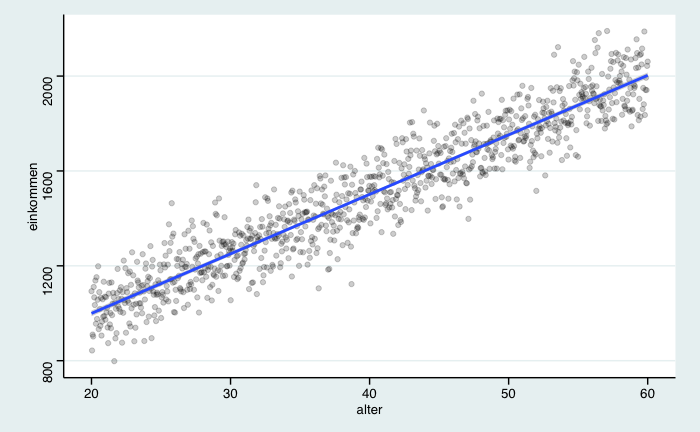

```r
ggplot(dt_raw, aes(x = alter, y = einkommen)) +
  geom_point(alpha = 0.2) +
  geom_smooth(method = lm) +
  theme_stata()
```

Wir stellen uns Postbeamte 📯 vor die regelmäßig Lohnerhöhungen 💰 strikt nach dem Senioritätsprinzip 🥸 erhalten.

Wir haben also ein Modell 📈 bei dem das **Einkommen** 💰 vom **Alter** 🧑👴 abhängt.

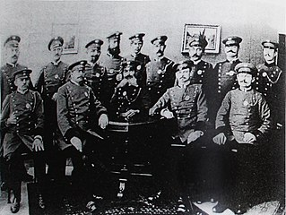

Das wahre Einkommen 💰 (`einkommen_linear`) ist uns bekannt und unsere beobachteten Daten 🕵️ (`einkommen`) weichen davon normal-verteilt 🧮 ab

So hat die Fee 🧚 uns die Daten 📊 gegeben.

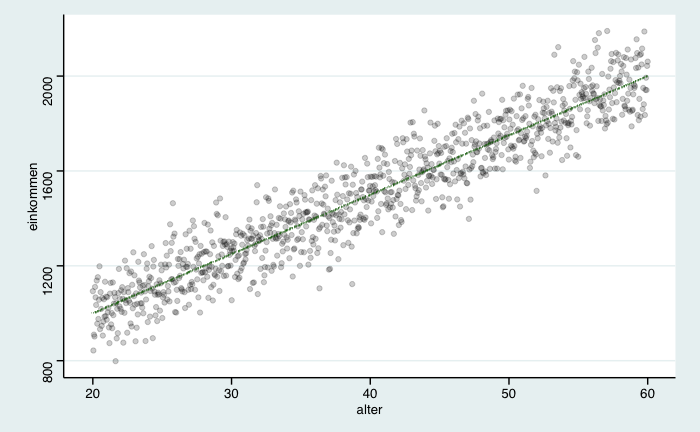

```r
ggplot(dt_raw, aes(x = alter, y = einkommen)) +
  geom_point(alpha = 0.2) +
  geom_jitter(aes(y = einkommen_linear),
              width = 0.1, alpha = 0.5,
              colour = "darkgreen", shape = ".") +
  theme_stata()
```

```r
DT::datatable(dt_raw)
```

|  | id | alter | einkommen_linear | einkommen |
| --- | --- | --- | --- | --- |
| 1 | 1 | 20 | 1000 | 1093 |
| 2 | 2 | 20.04 | 1001 | 843 |
| 3 | 3 | 20.08 | 1002 | 910 |
| 4 | 4 | 20.12 | 1003 | 902 |
| 5 | 5 | 20.16 | 1004 | 1111 |
| 6 | 6 | 20.2 | 1005 | 1067 |
| 7 | 7 | 20.24 | 1006 | 1035 |
| 8 | 8 | 20.28 | 1007 | 1138 |
| 9 | 9 | 20.32 | 1008 | 956 |
| 10 | 10 | 20.36 | 1009 | 1152 |

[output cut: 990 more lines]

## Modell (fast) perfekt

Wir bekommen schöne Ergebnisse bei der Schätzung des Modells. 😄

```r
fit <- lm(einkommen ~ alter, data = dt_raw)
tidy_lm(fit)
```

| term | estimate | std.error | statistic | p.value |
| --- | --- | --- | --- | --- |
| (Intercept) | 497.70 | 11.22 | 44.34 | 0 |
| alter | 25.09 | 0.27 | 93.07 | 0 |

```r
glance_lm(fit)
```

| r.squared | adj.r.squared | statistic | p.value | df | nobs |
| --- | --- | --- | --- | --- | --- |
| 0.9 | 0.9 | 8662.08 | 0 | 1 | 1000 |

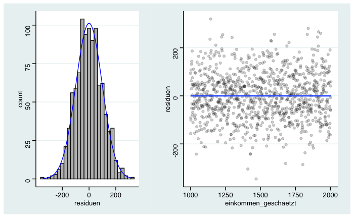

```r
plot_lm(fit)
```

## Annahmen (1-7)

1. korrekte Spezifikation (Linearität)
2. Erwartungswert der Residuen (lokal) = 0
3. Normalverteilte Residuen
4. Varianzhomogenität (gleichmäßige Streuung Residuen)
5. Berücksichtigung einflussreicher Fälle (keine Ausreisser)
6. *keine* Multikollinearität (geringe Korrelation unabhängiger Variablen)
7. *keine* Autokorrelation der Residuen (insbes. Zeitreihen)

# Binäre abhängige Variablen

Postbeamte 📯 sammeln natürlich auch gerne Briefmarken 📨. Am Anfang nur einige von ihnen (ca. 20%). Dann greift die Sozialisation 🧑‍🤝‍🧑 und zwischen 30 und 40 Jahren beginnen sehr viele mit dem Sammeln der Briefmarken. Von den über 40-jährigen sind es dann fast alle (ca. 90%)

[figure not shown]

```r
dt <-
  dt_raw %>%
  mutate(
    prob = case_when(alter < 30 ~ 0.2, alter >= 40 ~ 0.9, TRUE ~ 0.2 + (alter-30) * 0.07),
    sammler = map_int(prob, ~ rbinom(1, 1, prob = .x))
    )
```

```
Ignoring unknown parameters: binwidth, bins, pad
```

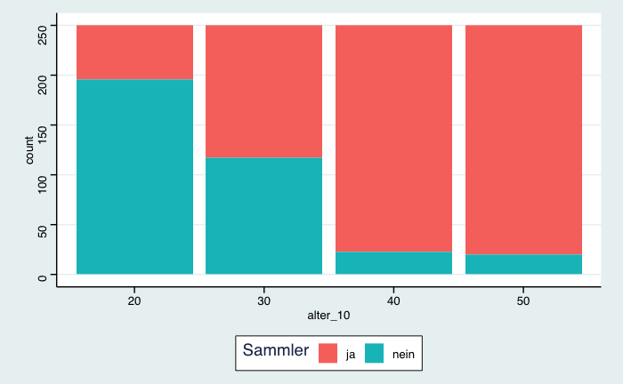

```r
dt2 <-
  dt %>%
  mutate(
    alter_10 = ifelse(alter >= 60, 59, alter),
    alter_10 = factor(alter_10%/%10 * 10),
    Sammler = factor(sammler, c(1, 0), c("ja", "nein"))
   )

ggplot(dt2, aes(x = alter_10, fill = Sammler)) +
  geom_histogram(stat = "count") +
  theme_stata()
```

## Lineares Wahrscheinlichkeits-Modell

Ein linerares Regressions-Modell 📈 erfüllt bei einer binären abhängigen Variablen die Modell-Annahmen nicht mehr 😟.

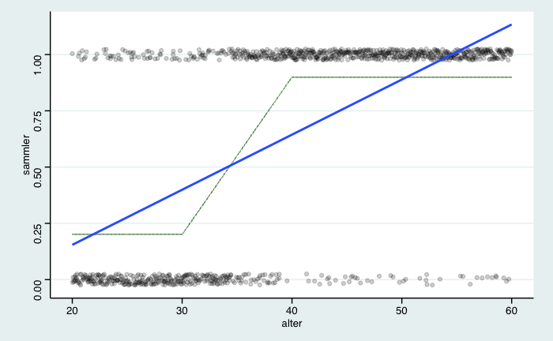

```r
ggplot(dt, aes(x = alter, y = sammler)) +
  geom_jitter(height = 0.025, alpha = 0.2) +
  geom_point(aes(y = prob), alpha = 0.5, colour = "darkgreen", shape = ".") +
  geom_smooth(method = "lm", se = FALSE) +
  scale_y_continuous(breaks = seq(0, 1, 0.25)) +
  theme_stata()
```

```r
fit <- lm(sammler ~ alter, data = dt)
tidy_lm(fit)
```

| term | estimate | std.error | statistic | p.value |
| --- | --- | --- | --- | --- |
| (Intercept) | -0.34 | 0.04 | -7.61 | 0 |
| alter | 0.02 | 0.00 | 23.14 | 0 |

```r
glance_lm(fit)
```

| r.squared | adj.r.squared | statistic | p.value | df | nobs |
| --- | --- | --- | --- | --- | --- |
| 0.35 | 0.35 | 535.56 | 0 | 1 | 1000 |

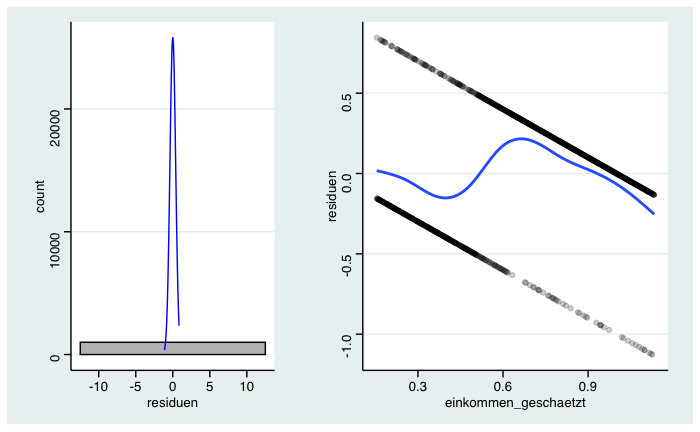

```r
plot_lm(fit)
```

## Logit-Modell

Besser 😀 geht es mit einer [Logistischen Regression](https://de.wikipedia.org/wiki/Logistische_Regression).

```r
fit <- glm(sammler ~ alter, data = dt, family = binomial(link = "logit"))
tidy_lm(fit)
```

| term | estimate | std.error | statistic | p.value |
| --- | --- | --- | --- | --- |
| (Intercept) | -4.96 | 0.35 | -14.38 | 0 |
| alter | 0.15 | 0.01 | 15.75 | 0 |

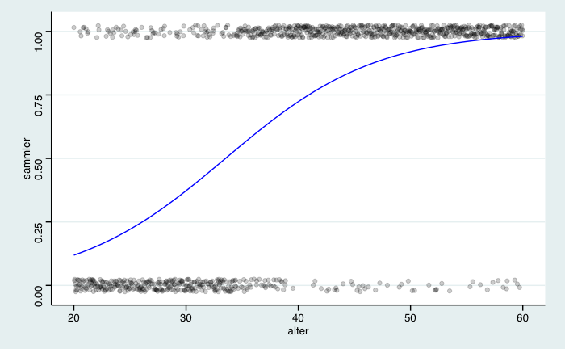

```r
dt <- augment(x=fit, newdata = dt, type.predict = "response")

ggplot(dt, aes(x = alter, y = sammler)) +
  geom_jitter(height = 0.025, alpha = 0.2) +
  geom_line(aes(x = alter, y = .fitted), colour = "blue") +
  theme_stata()
```

# Aufgabe

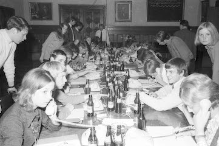

Diskutieren Sie 🙇🙇🙇 die Regressions-Annahmen 📈 und zeigen Sie ob und wie Verletzungen 🏥 der Annahmen erkannt 🕵️ werden können

# Quellen

- https://commons.wikimedia.org/wiki/File:SophieAndersonTakethefairfaceofWoman.jpg
- https://commons.wikimedia.org/wiki/File:Radioquiz_%22Allein_gegen_alle%22_aus_dem_Ratssaal_(Kiel_45.567).jpg
- https://de.wikipedia.org/wiki/Datei:DBP_1951_Posthorn_komplett.jpg

[figure not shown]

# Nachtrag

Wer genau 🕵️ auf die Simulation der Daten 📊geschaut hat wird einwenden, dass eine Regression mit Interaktion doch super 🤗 funktionieren müsste.

Genau 🙃! Um dies zu zeigen müssen wir die Anzahl der Beobachtungen etwas 📊 erhöhen.

Dies aber nur für alle die noch etwas knobeln 🤔 (und Interaktionen wiederholen) wollen.

```r
dt3 <-
  map_df(1:100, ~ dt2) %>%
  mutate(alter_10 = fct_collapse(alter_10, `40_50` = c("40", 50)))

fit <- lm(sammler ~ alter*alter_10, data = dt3)
tidy_lm(fit)
```

| term | estimate | std.error | statistic | p.value |
| --- | --- | --- | --- | --- |
| (Intercept) | 0.10 | 0.02 | 5.20 | 0 |
| alter | 0.00 | 0.00 | 5.65 | 0 |
| alter_1030 | -2.23 | 0.03 | -65.01 | 0 |
| alter_1040_50 | 0.80 | 0.02 | 32.55 | 0 |
| alter:alter_1030 | 0.07 | 0.00 | 63.63 | 0 |
| alter:alter_1040_50 | 0.00 | 0.00 | -5.01 | 0 |

```r
glance_lm(fit)
```

| r.squared | adj.r.squared | statistic | p.value | df | nobs |
| --- | --- | --- | --- | --- | --- |
| 0.43 | 0.43 | 14793.21 | 0 | 5 | 1e+05 |

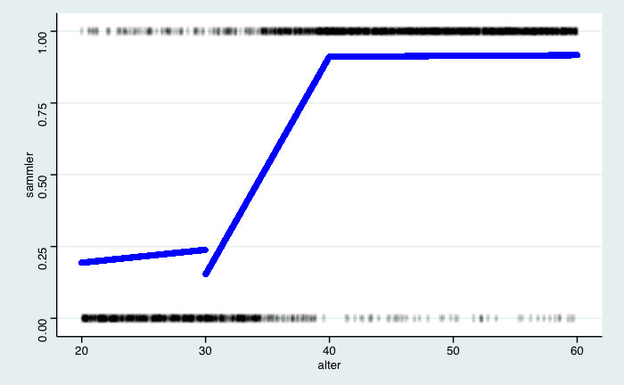

```r
dt3 <- augment(x=fit, newdata = dt3, type.predict = "response")

ggplot(dt3, aes(x = alter, y = sammler)) +
  geom_jitter(height = 0.0125, alpha = 0.0025) +
  geom_point(aes(x = alter, y = .fitted), colour = "blue") +
  theme_stata()
```